# vowel_duration

## Materials

At the start, we have audio and annotated textgrids of **regilaul** songs, annotated for ictus/off-ictus and phrase text, then force-aligned using Praat's built in eSpeak forced aligner for Estonian to word and then segment. Then, we use the estnltk vabamorf package to syllabify the words so that we can annotate the textgrid further with syllable quantity (Estonian has 3) and whether or not it is accented at the word level. We end up with a dataframe containing the data from three of the(Interval) tiers of the textgrid, acquiring duration data for words, individual segments, and (eventually) syllables.

```python
import parselmouth
from estnltk.vabamorf.morf import syllabify_word
import tgt
import string
#test method on a single TextGrid:
gridDir2 = "/Users/sarah/qp_final/txtgridtest/69.TextGrid"


def get_duration_labels(textgrid, tiername1,tiername2,tiername3):
    tmp = tgt.read_textgrid(textgrid)
    mytier = tmp.get_tier_by_name(tiername1)
    other = tmp.get_tier_by_name(tiername2)
    ictus = tmp.get_tier_by_name(tiername3)
    segments = []
    word_dur = mytier.intervals

    for interval in word_dur:
        h = interval.start_time
        t = interval.end_time
        b = t-h
        l = interval.text
        tmpseg = [other.get_annotations_between_timepoints(h,t)]
        s = syllabify_word(l,as_dict=True)
        i = 0
        for list in tmpseg:
            n = 0
            while i < len(s):
                item = s[i]
                shape = item.get('syllable')
                q = item.get('quantity')
                a = item.get('accent')
                geminate = False
                for char in shape.strip(string.punctuation):
                    if geminate: continue
                    if n < len(list):
                        myinterval = list[n]
                        c = myinterval.text
                        d = myinterval.start_time
                        g = myinterval.end_time
                        tmpick = ictus.get_annotations_between_timepoints(d,g,left_overlap=True,right_overlap=True)
                        if len(tmpick) == 0: ick = "off"
                        else: ick = "ictus"
                        #segment duration
                        j = g-d
                        #segment midpoint for later measurements
                        mid = g - (j/2)
                        if "ː" in c:
                            row = [l,b,shape,q,a,c,j,mid,ick]
                            segments.append(row)
                            geminate = True

                        elif char == c:

                            row = [l,b,shape,q,a,c,j,mid,ick]
                            segments.append(row)
                        else :
                            can = "(" + char + ") " + c
                            row = [l,b,shape,q,a,can,j,mid,ick]
                            segments.append(row)
                        n+=1
                i+= 1





    nu_df = pd.DataFrame(segments,columns=["word","word_dur","syll","quantity","stress","segment","seg_duration","seg_midpoint","ictus"])
    return nu_df

syl_dur_df = get_duration_labels(gridDir2,"word","word/phon","ictus")
syl_dur_df.head()
```

|  | word | word_dur | syll | quantity | stress | segment | seg_duration | seg_midpoint | ictus |
| --- | --- | --- | --- | --- | --- | --- | --- | --- | --- |
| 0 | Oh | 0.240882 | oh | 3 | 1 | o | 0.165043 | 0.082521 | ictus |
| 1 | Oh | 0.240882 | oh | 3 | 1 | h | 0.075839 | 0.202962 | ictus |
| 2 | me | 0.169500 | me | 3 | 1 | m | 0.059664 | 0.270713 | ictus |
| 3 | me | 0.169500 | me | 3 | 1 | e | 0.109836 | 0.355463 | ictus |
| 4 | vaesed | 0.619500 | vae | 2 | 1 | v | 0.101258 | 0.461010 | ictus |

## Adding Spectral data

now that we have the duration data from the textgrid, we can query specific timepoints for information about the acoustic signal. The following function uses the midpoint (which we snagged while we were making the dataframe above) and get the first three formants(Hz) for each segment.

```python
import parselmouth

test = "/Users/sarah/qp_final/wavs/069.wav"

def get_formants(syl_dur_df, wave):
    song = parselmouth.Sound(wave)
    formant = song.to_formant_burg()
    f1 = []
    f2 = []
    f3 = []
    for float in syl_dur_df.seg_midpoint:
        time = float
        f1.append(formant.get_value_at_time(1,time))
        f2.append(formant.get_value_at_time(2, time))
        f3.append(formant.get_value_at_time(3,time))
    syl_dur_df["f1"] = f1
    syl_dur_df["f2"] = f2
    syl_dur_df["f3"] = f3
    return syl_dur_df
nu_df = get_formants(syl_dur_df,test)
nu_df.head()
```

|  | word | word_dur | syll | quantity | stress | segment | seg_duration | seg_midpoint | ictus | f1 | f2 | f3 |
| --- | --- | --- | --- | --- | --- | --- | --- | --- | --- | --- | --- | --- |
| 0 | Oh | 0.240882 | oh | 3 | 1 | o | 0.165043 | 0.082521 | ictus | 540.905421 | 989.905678 | 1414.238432 |
| 1 | Oh | 0.240882 | oh | 3 | 1 | h | 0.075839 | 0.202962 | ictus | 850.865128 | 1620.784985 | 2186.523346 |
| 2 | me | 0.169500 | me | 3 | 1 | m | 0.059664 | 0.270713 | ictus | 346.158399 | 1818.412065 | 2798.007639 |
| 3 | me | 0.169500 | me | 3 | 1 | e | 0.109836 | 0.355463 | ictus | 411.766557 | 1385.397329 | 2214.984918 |
| 4 | vaesed | 0.619500 | vae | 2 | 1 | v | 0.101258 | 0.461010 | ictus | 488.221699 | 1013.678738 | 1576.019602 |

```python
from os.path import join
#runs a for loop over a directory using the above-specified functions

test = "/Users/sarah/qp_final/txtgridtest/"
songs = "/Users/sarah/qp_final/songs/"

for fn in os.listdir(test):
    if '.TextGrid' not in fn:
        continue
    n = fn.strip('.TextGrid')
    wave = join(songs, n + '.wav')
    data_file = open("ictus_forms_" + n +".csv",'w')
    #make a dataframe with the interval tiers of the textgrid
    tmp = pd.DataFrame(get_duration_labels(join(test,fn), "word","word/phon","ictus"))
    #add the formant data to the dataframe
    nu_df = get_formants(tmp,wave)
    print(nu_df.head())
    # nu_df.to_csv(data_file)
    # data_file.close()
```

```
    word  word_dur syll  quantity  stress segment  seg_duration  seg_midpoint  \
0  Lõpe,  0.877833   lõ         2       1       l      0.102860      0.206697
1  Lõpe,  0.877833   lõ         2       1   (õ) ɵ      0.293082      0.404668
2  Lõpe,  0.877833  pe,         2       0       p      0.191140      0.646779
3  Lõpe,  0.877833  pe,         2       0       e      0.290751      0.887725
4  lõpe,  0.836977   lõ         2       1       l      0.075601      1.070901

   ictus          f1           f2           f3
0  ictus  335.422530  1063.568157  1890.268233
1  ictus  684.001970  1113.986905  1962.573748
2  ictus  408.802542  1208.989186  2321.386963
3    off  758.503513  1717.665908  2219.432604
4  ictus  772.408953  1868.617726  1966.346496
   word  word_dur  syll  quantity  stress segment  seg_duration  seg_midpoint  \
0  miks  0.334037  miks         3       1       m      0.109658      2.583638
```

[output cut: 102 more lines]

# Now we put it into a big pile!

Here we concatenate all the data we have so far into one large pandas dataframe. At this point, we can keep annotating songs for the corpus, and as textgrids are finished we can run the scripts above to add them into the larger dataset. We're also gonna take the opportunity to add some metadata to the dataframes: fileid(song) and performer initials as potential grouping factors.

```python
import os
import pandas as pd
import statsmodels .formula.api as smf
folder = "/Users/sarah/qp_final/data_glob/"
meta =  pd.read_csv("/Users/sarah/qp_final/song_metadata.csv")


songs_dfs = []
for fn in os.listdir(folder):
    if '.csv' not in fn: continue
    whole_name = os.path.join(folder,fn)
    song_df = pd.read_csv(whole_name)
    fileid1 = fn.strip('ictus_forms_')
    fileid = int(fileid1.strip('.csv'))
    row = meta.index[meta['track'] == fileid].tolist()
    performer = meta.performer[row[0]]
    for index in song_df:
        song_df['fileid'] = fileid
        song_df['performer'] = performer


    songs_dfs.append(song_df)

big_frame = pd.concat(songs_dfs, ignore_index=True)
print(big_frame.describe())
big_frame
```

```
        Unnamed: 0     word_dur     quantity       stress  seg_duration  \
count  1967.000000  1967.000000  1967.000000  1967.000000   1967.000000
mean    198.710727     0.927221     1.887646     0.522623      0.139460
std     192.058558     0.467994     0.649035     0.499615      0.096460
min       0.000000     0.083718     1.000000     0.000000      0.004193
25%      56.000000     0.566898     1.000000     0.000000      0.076177
50%     131.000000     0.819799     2.000000     1.000000      0.109868
75%     259.000000     1.304484     2.000000     1.000000      0.180858
max     734.000000     2.168336     3.000000     1.000000      1.201817

       seg_midpoint           f1           f2           f3       fileid
count   1967.000000  1966.000000  1966.000000  1966.000000  1967.000000
mean      57.490687   705.838851  1570.350446  2466.377994    43.916116
std       60.299049   202.075224   389.769265   331.870332    29.497152
min        0.002097   275.170888   519.638388  1204.360788     9.000000
25%       14.617182   548.215226  1296.586430  2290.649062    18.000000
50%       32.759004   694.356670  1529.016068  2496.860314    41.000000
75%       82.097020   855.569626  1831.690906  2669.113021    65.000000
max      219.349440  1472.974201  2693.060094  3552.062191    94.000000
```

|  | Unnamed: 0 | word | word_dur | syll | quantity | stress | segment | seg_duration | seg_midpoint | ictus | f1 | f2 | f3 | fileid | performer |
| --- | --- | --- | --- | --- | --- | --- | --- | --- | --- | --- | --- | --- | --- | --- | --- |
| 0 | 0 | pandi | 0.456740 | pan | 2 | 1 | p | 0.047328 | 6.835351 | ictus | 605.862912 | 1068.944908 | 2291.317753 | 65 | LK |
| 1 | 1 | pandi | 0.456740 | pan | 2 | 1 | a | 0.177026 | 6.947528 | ictus | 603.056801 | 1303.781807 | 2625.465878 | 65 | LK |
| 2 | 2 | pandi | 0.456740 | pan | 2 | 1 | (n) ɲ | 0.041698 | 7.056890 | ictus | 765.874507 | 1279.851220 | 2546.395265 | 65 | LK |
| 3 | 3 | pandi | 0.456740 | di | 1 | 0 | d | 0.059916 | 7.107697 | off | 930.416284 | 1876.949848 | 2542.774896 | 65 | LK |
| 4 | 4 | pandi | 0.456740 | di | 1 | 0 | i | 0.129039 | 7.202174 | off | 1074.849998 | 2167.095173 | 2671.989524 | 65 | LK |
| ... | ... | ... | ... | ... | ... | ... | ... | ... | ... | ... | ... | ... | ... | ... | ... |
| 1962 | 34 | sulased, | 0.772673 | la | 1 | 0 | l | 0.056635 | 8.946193 | ictus | 935.586178 | 2102.100627 | 3341.040339 | 69 | LO |
| 1963 | 35 | sulased, | 0.772673 | la | 1 | 0 | (a) ɑ | 0.152365 | 9.050693 | ictus | 564.758290 | 1384.443183 | 3073.026293 | 69 | LO |
| 1964 | 36 | sulased, | 0.772673 | sed, | 3 | 1 | s | 0.093000 | 9.173375 | ictus | 1298.894426 | 1954.360862 | 3033.911307 | 69 | LO |
| 1965 | 37 | sulased, | 0.772673 | sed, | 3 | 1 | e | 0.144135 | 9.291943 | off | 909.702594 | 1747.600824 | 2806.347885 | 69 | LO |
| 1966 | 38 | sulased, | 0.772673 | sed, | 3 | 1 | d | 0.078979 | 9.403500 | ictus | 840.561088 | 1461.144276 | 1987.093716 | 69 | LO |

1967 rows × 15 columns

```python
#for the present paper, we are only interested in the vowel durations:
#set of Estonian vowels to filter the dataframe:
vowels = ["i","ɪ","y","e","ɛ","ø","æ","a","ɑ","ɵ","o","ʊ","u","ʎ" ]
vowel_df = big_frame[big_frame.segment.isin(vowels)].copy()
print(vowel_df.describe())
vowel_df.head()
```

```
       Unnamed: 0    word_dur    quantity      stress  seg_duration  \
count  615.000000  615.000000  615.000000  615.000000    615.000000
mean   197.894309    0.949184    1.852033    0.528455      0.197959
std    190.819594    0.492294    0.684323    0.499596      0.117456
min      0.000000    0.083718    1.000000    0.000000      0.015260
25%     57.500000    0.555927    1.000000    0.000000      0.131685
50%    132.000000    0.846330    2.000000    1.000000      0.178758
75%    259.000000    1.335653    2.000000    1.000000      0.236604
max    734.000000    2.168336    3.000000    1.000000      1.201817

       seg_midpoint           f1           f2           f3      fileid
count    615.000000   615.000000   615.000000   615.000000  615.000000
mean      57.435001   720.172015  1565.957831  2467.122054   44.450407
std       59.849928   198.120808   396.035823   332.652632   29.328873
min        0.051613   275.499384   519.638388  1396.638475    9.000000
25%       15.556456   567.050872  1262.772049  2300.155478   18.000000
50%       33.763837   703.407720  1523.729941  2496.694808   41.000000
75%       78.970333   867.648661  1838.565263  2663.815935   65.000000
max      219.349440  1219.144093  2693.060094  3331.398284   94.000000
```

|  | Unnamed: 0 | word | word_dur | syll | quantity | stress | segment | seg_duration | seg_midpoint | ictus | f1 | f2 | f3 | fileid | performer |
| --- | --- | --- | --- | --- | --- | --- | --- | --- | --- | --- | --- | --- | --- | --- | --- |
| 1 | 1 | pandi | 0.456740 | pan | 2 | 1 | a | 0.177026 | 6.947528 | ictus | 603.056801 | 1303.781807 | 2625.465878 | 65 | LK |
| 4 | 4 | pandi | 0.456740 | di | 1 | 0 | i | 0.129039 | 7.202174 | off | 1074.849998 | 2167.095173 | 2671.989524 | 65 | LK |
| 6 | 6 | mind(e) | 0.292967 | mind | 2 | 1 | i | 0.085210 | 7.364037 | off | 731.376613 | 1651.342030 | 2557.796933 | 65 | LK |
| 9 | 9 | mind(e) | 0.292967 | (e) | 2 | 0 | e | 0.067737 | 7.527525 | off | 852.719874 | 1444.954754 | 2241.764747 | 65 | LK |
| 11 | 11 | paju | 0.881775 | pa | 1 | 1 | a | 0.386617 | 7.887546 | ictus | 794.798321 | 850.845027 | 2525.457521 | 65 | LK |

```python
#make sure quantity is read as a categorical variable
vowel_df['quantity'] = vowel_df['quantity'].astype('object')
vowel_df['stress'] = vowel_df['stress'].astype('object')
print("vowel duration and stressed/unstressed: \n" , vowel_df.groupby('stress')['seg_duration'].mean())
print("vowel duration and syllable quantity: \n" , vowel_df.groupby('quantity')['seg_duration'].mean())
print("vowel duration and ictus/off-ictus \n" , vowel_df.groupby('ictus')['seg_duration'].mean())
```

```
vowel duration and stressed/unstressed:
 stress
0    0.228611
1    0.170609
Name: seg_duration, dtype: float64
vowel duration and syllable quantity:
 quantity
1    0.216361
2    0.205660
3    0.140581
Name: seg_duration, dtype: float64
vowel duration and ictus/off-ictus
 ictus
ictus    0.202398
off      0.191118
Name: seg_duration, dtype: float64
```

```python
import pandas as pd
import statsmodels .formula.api as smf

#is ictus (song prominence) a good predictor for vowel duration?

ickmodel = smf.ols("seg_duration ~ ictus", data=vowel_df).fit()
ickmodel.summary()
```

OLS Regression Results

| Dep. Variable: | seg_duration | R-squared: | 0.002 |
| --- | --- | --- | --- |
| Model: | OLS | Adj. R-squared: | 0.001 |
| Method: | Least Squares | F-statistic: | 1.355 |
| Date: | Thu, 12 May 2022 | Prob (F-statistic): | 0.245 |
| Time: | 00:26:19 | Log-Likelihood: | 445.67 |
| No. Observations: | 615 | AIC: | -887.3 |
| Df Residuals: | 613 | BIC: | -878.5 |
| Df Model: | 1 |  |  |
| Covariance Type: | nonrobust |  |  |

|  | coef | std err | t | P>\|t\| | [0.025 | 0.975] |
| --- | --- | --- | --- | --- | --- | --- |
| Intercept | 0.2024 | 0.006 | 33.290 | 0.000 | 0.190 | 0.214 |
| ictus[T.off] | -0.0113 | 0.010 | -1.164 | 0.245 | -0.030 | 0.008 |

| Omnibus: | 496.206 | Durbin-Watson: | 1.603 |
| --- | --- | --- | --- |
| Prob(Omnibus): | 0.000 | Jarque-Bera (JB): | 11531.163 |
| Skew: | 3.442 | Prob(JB): | 0.00 |
| Kurtosis: | 23.065 | Cond. No. | 2.44 |

Notes:  
[1] Standard Errors assume that the covariance matrix of the errors is correctly specified.

```
min:  -0.17585777802014163 q1:  -0.06790367526020552 median:  -0.019300475934164396 q3:  0.03725672678702266 max:  1.0106989261669985
```

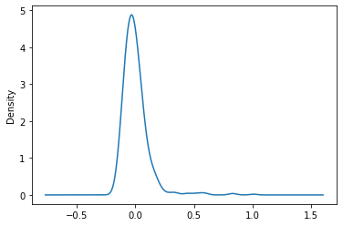

```python
ickmodel.fittedvalues
resid_series = pd.Series(ickmodel.resid)
print("min: " ,resid_series.min(), "q1: ", resid_series.quantile(0.25), "median: " ,resid_series.median(),"q3: " , resid_series.quantile(0.75),"max: " ,resid_series.max())
pd.Series(ickmodel.resid).plot.density();
```

Let's see how quantity is shaking out:

```python
qmodel = smf.ols("seg_duration ~ quantity", data=vowel_df).fit()
qmodel.summary()
```

OLS Regression Results

| Dep. Variable: | seg_duration | R-squared: | 0.051 |
| --- | --- | --- | --- |
| Model: | OLS | Adj. R-squared: | 0.048 |
| Method: | Least Squares | F-statistic: | 16.39 |
| Date: | Thu, 12 May 2022 | Prob (F-statistic): | 1.16e-07 |
| Time: | 00:26:19 | Log-Likelihood: | 461.04 |
| No. Observations: | 615 | AIC: | -916.1 |
| Df Residuals: | 612 | BIC: | -902.8 |
| Df Model: | 2 |  |  |
| Covariance Type: | nonrobust |  |  |

|  | coef | std err | t | P>\|t\| | [0.025 | 0.975] |
| --- | --- | --- | --- | --- | --- | --- |
| Intercept | 0.2164 | 0.008 | 26.428 | 0.000 | 0.200 | 0.232 |
| quantity[T.2] | -0.0107 | 0.010 | -1.026 | 0.305 | -0.031 | 0.010 |
| quantity[T.3] | -0.0758 | 0.014 | -5.467 | 0.000 | -0.103 | -0.049 |

| Omnibus: | 508.017 | Durbin-Watson: | 1.666 |
| --- | --- | --- | --- |
| Prob(Omnibus): | 0.000 | Jarque-Bera (JB): | 12614.124 |
| Skew: | 3.541 | Prob(JB): | 0.00 |
| Kurtosis: | 24.026 | Cond. No. | 4.12 |

Notes:  
[1] Standard Errors assume that the covariance matrix of the errors is correctly specified.

Well, we have significant p values for the first (Q1) and third (Q3) coefficients, but not the second (Q2). This makes sense, since the quantity contrast is indicated by the duration ratios of the syllables. Q3, however, never appears in an unstressed position in a word, so only needs to be contrasted with Q2, while Q1 and Q2 both appear in stressed and unstressed positions and need to be differentiated from each other. The adj r-squared here is a little bit better than the ictus model above, and we do have statistical significance for the model overall (p<0.0000)

```
min:  -0.20110167790250655 q1:  -0.060080153917226674 median:  -0.021591012703996354 q3:  0.0328693256575211 max:  0.9961566923675012
```

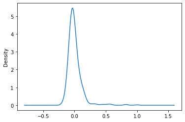

```python
qmodel.fittedvalues
qresid_series = pd.Series(qmodel.resid)
print("min: " ,qresid_series.min(), "q1: ", qresid_series.quantile(0.25), "median: " ,qresid_series.median(),"q3: " , qresid_series.quantile(0.75),"max: " ,qresid_series.max())
pd.Series(qmodel.resid).plot.density();
```

```python
stressmodel = smf.ols("seg_duration ~ stress", data=vowel_df).fit()
stressmodel.summary()
```

OLS Regression Results

| Dep. Variable: | seg_duration | R-squared: | 0.061 |
| --- | --- | --- | --- |
| Model: | OLS | Adj. R-squared: | 0.059 |
| Method: | Least Squares | F-statistic: | 39.73 |
| Date: | Thu, 12 May 2022 | Prob (F-statistic): | 5.58e-10 |
| Time: | 00:26:20 | Log-Likelihood: | 464.31 |
| No. Observations: | 615 | AIC: | -924.6 |
| Df Residuals: | 613 | BIC: | -915.8 |
| Df Model: | 1 |  |  |
| Covariance Type: | nonrobust |  |  |

|  | coef | std err | t | P>\|t\| | [0.025 | 0.975] |
| --- | --- | --- | --- | --- | --- | --- |
| Intercept | 0.2286 | 0.007 | 34.175 | 0.000 | 0.215 | 0.242 |
| stress | -0.0580 | 0.009 | -6.303 | 0.000 | -0.076 | -0.040 |

| Omnibus: | 476.606 | Durbin-Watson: | 1.635 |
| --- | --- | --- | --- |
| Prob(Omnibus): | 0.000 | Jarque-Bera (JB): | 10197.558 |
| Skew: | 3.270 | Prob(JB): | 0.00 |
| Kurtosis: | 21.847 | Cond. No. | 2.69 |

Notes:  
[1] Standard Errors assume that the covariance matrix of the errors is correctly specified.

here we have significant effects for both coefficients. It looks like word-level stress predicts a shorter vowel duration, with a negative slope.

```python
stress_q_model = smf.ols("seg_duration ~ stress + quantity", data=vowel_df).fit()
stress_q_model.summary()
```

OLS Regression Results

| Dep. Variable: | seg_duration | R-squared: | 0.077 |
| --- | --- | --- | --- |
| Model: | OLS | Adj. R-squared: | 0.073 |
| Method: | Least Squares | F-statistic: | 17.10 |
| Date: | Thu, 12 May 2022 | Prob (F-statistic): | 1.12e-10 |
| Time: | 00:43:32 | Log-Likelihood: | 469.79 |
| No. Observations: | 615 | AIC: | -931.6 |
| Df Residuals: | 611 | BIC: | -913.9 |
| Df Model: | 3 |  |  |
| Covariance Type: | nonrobust |  |  |

|  | coef | std err | t | P>\|t\| | [0.025 | 0.975] |
| --- | --- | --- | --- | --- | --- | --- |
| Intercept | 0.2300 | 0.009 | 26.414 | 0.000 | 0.213 | 0.247 |
| stress[T.1] | -0.0432 | 0.010 | -4.200 | 0.000 | -0.063 | -0.023 |
| quantity[T.2] | -0.0026 | 0.010 | -0.251 | 0.802 | -0.023 | 0.018 |
| quantity[T.3] | -0.0462 | 0.015 | -3.007 | 0.003 | -0.076 | -0.016 |

| Omnibus: | 488.788 | Durbin-Watson: | 1.653 |
| --- | --- | --- | --- |
| Prob(Omnibus): | 0.000 | Jarque-Bera (JB): | 11163.529 |
| Skew: | 3.370 | Prob(JB): | 0.00 |
| Kurtosis: | 22.754 | Cond. No. | 4.99 |

Notes:  
[1] Standard Errors assume that the covariance matrix of the errors is correctly specified.

so far, this is the best model we have as far as adj r-squared goes. It is explaining the most variation so far, and it is unlikely with the low p value that the model is complete trash. We didn't lose significance for any of our coefficients from single factor models.

```
min:  -0.19704059472321775 q1:  -0.06306568545920294 median:  -0.020152767123178622 q3:  0.03726678408654223 max:  0.974420464328187
```

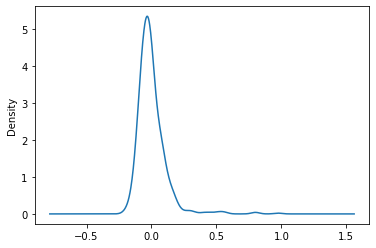

```python
stress_q_model.fittedvalues
stressresid_series = pd.Series(stress_q_model.resid)
print("min: " ,stressresid_series.min(), "q1: ", stressresid_series.quantile(0.25), "median: " ,stressresid_series.median(),"q3: " , stressresid_series.quantile(0.75),"max: " ,stressresid_series.max())
pd.Series(stress_q_model.resid).plot.density();
```